# Trip Generation Analysis - SVC790 Part A

R. Lubega

2026-09-09

## 1 Overview

Dependent variable: `N_trips`. Predictors: `Nr_People_H`, `Elderly`, `Educ_HS`, `Educ_Tertiary`, `Workers_Fulltime`, `Workers_Parttime`, `Learners_students`, `Driv_Lic`.

```r
if (!requireNamespace("readxl", quietly = TRUE))  install.packages("readxl")
if (!requireNamespace("corrplot", quietly = TRUE)) install.packages("corrplot")

library(readxl)
library(corrplot)

if (!dir.exists("figures")) dir.create("figures")
```

## 2 Load data

The sheet has a title block in rows 1-9; the real header row is row 10, so we skip the first 9 rows when reading.

```r
xlsx_path <- "RLubega SVC790_Part A_2026.xlsx"

raw <- read_excel(xlsx_path, sheet = "Table 1", skip = 9)

predictors <- c("Nr_People_H", "Elderly", "Educ_HS", "Educ_Tertiary",
                 "Workers_Fulltime", "Workers_Parttime",
                 "Learners_students", "Driv_Lic")

vars <- c("N_trips", predictors)

data <- raw[, vars]
data[] <- lapply(data, function(x) as.numeric(x))

cat("Rows read:", nrow(data), "\n")
```

```
## Rows read: 5387
```

```r
cat("Rows with at least one NA among analysis variables:",
    sum(!complete.cases(data)), "\n")
```

```
## Rows with at least one NA among analysis variables: 71
```

## 3 1. Correlation matrix and ellipse plot

```r
cor_mat <- cor(data[, vars], use = "complete.obs")
round(cor_mat, 3)
```

```
##                   N_trips Nr_People_H Elderly Educ_HS Educ_Tertiary
## N_trips             1.000       0.411   0.196   0.240         0.121
## Nr_People_H         0.411       1.000   0.568   0.139         0.026
## Elderly             0.196       0.568   1.000   0.043         0.018
## Educ_HS             0.240       0.139   0.043   1.000        -0.279
## Educ_Tertiary       0.121       0.026   0.018  -0.279         1.000
## Workers_Fulltime    0.230       0.118   0.069   0.252         0.343
## Workers_Parttime    0.142       0.017   0.005   0.044        -0.028
## Learners_students   0.545       0.271   0.135  -0.013        -0.010
## Driv_Lic            0.108       0.017  -0.013   0.074         0.385
##                   Workers_Fulltime Workers_Parttime Learners_students Driv_Lic
## N_trips                      0.230            0.142             0.545    0.108
## Nr_People_H                  0.118            0.017             0.271    0.017
## Elderly                      0.069            0.005             0.135   -0.013
## Educ_HS                      0.252            0.044            -0.013    0.074
## Educ_Tertiary                0.343           -0.028            -0.010    0.385
## Workers_Fulltime             1.000           -0.164            -0.012    0.373
## Workers_Parttime            -0.164            1.000             0.025   -0.041
## Learners_students           -0.012            0.025             1.000   -0.073
## Driv_Lic                     0.373           -0.041            -0.073    1.000
```

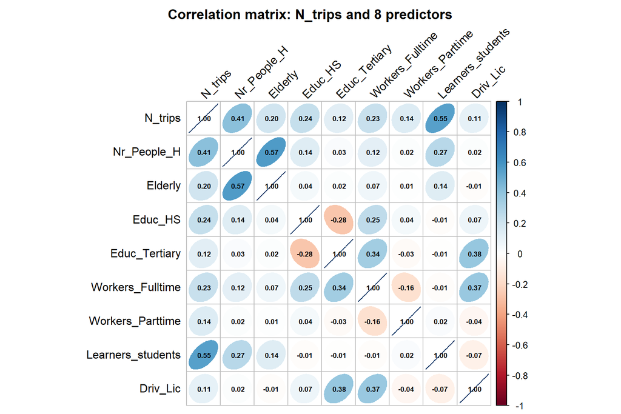

Correlation matrix: N_trips and 8 predictors

```r
corrplot(cor_mat, method = "ellipse", type = "full",
         tl.col = "black", tl.srt = 45,
         addCoef.col = "black", number.cex = 0.6,
         title = "Correlation matrix: N_trips and 8 predictors",
         mar = c(0, 0, 2, 0))
```

```r
png("figures/correlation_ellipse.png", width = 1000, height = 1000, res = 150)
corrplot(cor_mat, method = "ellipse", type = "full",
         tl.col = "black", tl.srt = 45,
         addCoef.col = "black", number.cex = 0.6,
         title = "Correlation matrix: N_trips and 8 predictors",
         mar = c(0, 0, 2, 0))
dev.off()
```

## 4 2. Scatterplots of N_trips against each predictor

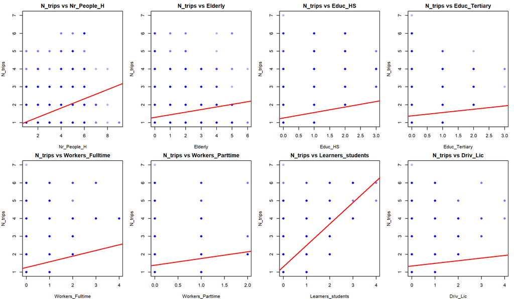

N_trips vs each of the 8 predictors

```r
par(mfrow = c(2, 4), mar = c(4, 4, 2, 1))
for (p in predictors) {
  plot(data[[p]], data[["N_trips"]],
       xlab = p, ylab = "N_trips",
       main = paste("N_trips vs", p),
       pch = 16, col = rgb(0, 0, 1, 0.3))
  abline(lm(data[["N_trips"]] ~ data[[p]]), col = "red", lwd = 2)
}
```

```r
png("figures/scatterplots.png", width = 1400, height = 900, res = 150)
par(mfrow = c(2, 4), mar = c(4, 4, 2, 1))
for (p in predictors) {
  plot(data[[p]], data[["N_trips"]],
       xlab = p, ylab = "N_trips",
       main = paste("N_trips vs", p),
       pch = 16, col = rgb(0, 0, 1, 0.3))
  abline(lm(data[["N_trips"]] ~ data[[p]]), col = "red", lwd = 2)
}
dev.off()
```

## 5 3. VIF for the full 8-predictor model (manual, base R only)

VIF is computed manually via auxiliary regressions: each predictor is regressed on the other 7, and `VIF = 1 / (1 - R2_aux)`. No `car` package is used.

```r
vif_data <- data[complete.cases(data[, predictors]), predictors]

vif_values <- sapply(predictors, function(p) {
  other <- setdiff(predictors, p)
  form  <- as.formula(paste(p, "~", paste(other, collapse = " + ")))
  r2_aux <- summary(lm(form, data = vif_data))$r.squared
  1 / (1 - r2_aux)
})

vif_table <- data.frame(Predictor = predictors,
                         R2_aux = round(sapply(predictors, function(p) {
                           other <- setdiff(predictors, p)
                           form  <- as.formula(paste(p, "~", paste(other, collapse = " + ")))
                           summary(lm(form, data = vif_data))$r.squared
                         }), 4),
                         VIF = round(vif_values, 3))

knitr::kable(vif_table, row.names = FALSE)
```

| Predictor | R2_aux | VIF |
| --- | --- | --- |
| Nr_People_H | 0.3795 | 1.612 |
| Elderly | 0.3253 | 1.482 |
| Educ_HS | 0.2473 | 1.329 |
| Educ_Tertiary | 0.3363 | 1.507 |
| Workers_Fulltime | 0.3151 | 1.460 |
| Workers_Parttime | 0.0407 | 1.042 |
| Learners_students | 0.0829 | 1.090 |
| Driv_Lic | 0.2286 | 1.296 |

## 6 4. Fit the six models

```r
modelA <- lm(N_trips ~ Nr_People_H, data = data)
modelB <- lm(N_trips ~ Nr_People_H + Driv_Lic, data = data)
modelC <- lm(N_trips ~ Learners_students + Workers_Fulltime + Driv_Lic, data = data)
modelD <- lm(N_trips ~ Nr_People_H + Elderly + Educ_HS + Educ_Tertiary +
                        Workers_Fulltime + Workers_Parttime +
                        Learners_students + Driv_Lic, data = data)
modelE <- lm(N_trips ~ Nr_People_H + Learners_students + Driv_Lic, data = data)
modelF <- lm(N_trips ~ Nr_People_H + Workers_Fulltime + Learners_students, data = data)

models <- list(A = modelA, B = modelB, C = modelC,
                D = modelD, E = modelE, F = modelF)
```

````r
for (nm in names(models)) {
  cat("### Model", nm, ":", deparse(formula(models[[nm]])), "\n\n")
  cat("```\n")
  print(summary(models[[nm]]))
  cat("```\n\n")
}
````

### 6.1 Model A : N_trips ~ Nr_People_H

```
Call:
lm(formula = N_trips ~ Nr_People_H, data = data)

Residuals:
    Min      1Q  Median      3Q     Max
-2.1149 -0.2996 -0.0403  0.1817  4.1817

Coefficients:
            Estimate Std. Error t value Pr(>|t|)
(Intercept) 0.780985   0.019963   39.12   <2e-16 ***
Nr_People_H 0.259329   0.007157   36.24   <2e-16 ***
---
Signif. codes:  0 '***' 0.001 '**' 0.01 '*' 0.05 '.' 0.1 ' ' 1

Residual standard error: 0.6959 on 5380 degrees of freedom
  (5 observations deleted due to missingness)
Multiple R-squared:  0.1962,    Adjusted R-squared:  0.196
F-statistic:  1313 on 1 and 5380 DF,  p-value: < 2.2e-16
```

### 6.2 Model B : N_trips ~ Nr_People_H + Driv_Lic

```
Call:
lm(formula = N_trips ~ Nr_People_H + Driv_Lic, data = data)

Residuals:
    Min      1Q  Median      3Q     Max
-2.0341 -0.3621 -0.1043  0.2475  4.2549

Coefficients:
            Estimate Std. Error t value Pr(>|t|)
(Intercept) 0.713830   0.021370   33.40   <2e-16 ***
Nr_People_H 0.257808   0.007113   36.25   <2e-16 ***
Driv_Lic    0.132613   0.015713    8.44   <2e-16 ***
---
Signif. codes:  0 '***' 0.001 '**' 0.01 '*' 0.05 '.' 0.1 ' ' 1

Residual standard error: 0.6914 on 5379 degrees of freedom
  (5 observations deleted due to missingness)
Multiple R-squared:  0.2067,    Adjusted R-squared:  0.2064
F-statistic: 700.7 on 2 and 5379 DF,  p-value: < 2.2e-16
```

### 6.3 Model C : N_trips ~ Learners_students + Workers_Fulltime + Driv_Lic

```
Call:
lm(formula = N_trips ~ Learners_students + Workers_Fulltime +
    Driv_Lic, data = data)

Residuals:
    Min      1Q  Median      3Q     Max
-1.5201 -0.3902 -0.1098  0.2392  5.8902

Coefficients:
                  Estimate Std. Error t value Pr(>|t|)
(Intercept)        1.10984    0.01214  91.428  < 2e-16 ***
Learners_students  1.20513    0.02110  57.122  < 2e-16 ***
Workers_Fulltime   0.28037    0.01475  19.013  < 2e-16 ***
Driv_Lic           0.09025    0.01481   6.095 1.17e-09 ***
---
Signif. codes:  0 '***' 0.001 '**' 0.01 '*' 0.05 '.' 0.1 ' ' 1

Residual standard error: 0.6022 on 5383 degrees of freedom
Multiple R-squared:  0.4141,    Adjusted R-squared:  0.4138
F-statistic:  1268 on 3 and 5383 DF,  p-value: < 2.2e-16
```

### 6.4 Model D : N_trips ~ Nr_People_H + Elderly + Educ_HS + Educ_Tertiary + Workers_Fulltime + Workers_Parttime + Learners_students + Driv_Lic

```
Call:
lm(formula = N_trips ~ Nr_People_H + Elderly + Educ_HS + Educ_Tertiary +
    Workers_Fulltime + Workers_Parttime + Learners_students +
    Driv_Lic, data = data)

Residuals:
    Min      1Q  Median      3Q     Max
-1.4694 -0.3225 -0.0975  0.1641  4.3515

Coefficients:
                   Estimate Std. Error t value Pr(>|t|)
(Intercept)        0.706093   0.016793  42.048   <2e-16 ***
Nr_People_H        0.129836   0.006671  19.464   <2e-16 ***
Elderly           -0.021507   0.008972  -2.397   0.0166 *
Educ_HS            0.233347   0.012779  18.260   <2e-16 ***
Educ_Tertiary      0.187435   0.018083  10.365   <2e-16 ***
Workers_Fulltime   0.144875   0.014090  10.282   <2e-16 ***
Workers_Parttime   0.336228   0.024048  13.982   <2e-16 ***
Learners_students  0.984266   0.020920  47.049   <2e-16 ***
Driv_Lic           0.040696   0.013166   3.091   0.0020 **
---
Signif. codes:  0 '***' 0.001 '**' 0.01 '*' 0.05 '.' 0.1 ' ' 1

Residual standard error: 0.4992 on 5307 degrees of freedom
  (71 observations deleted due to missingness)
Multiple R-squared:  0.4781,    Adjusted R-squared:  0.4773
F-statistic: 607.8 on 8 and 5307 DF,  p-value: < 2.2e-16
```

### 6.5 Model E : N_trips ~ Nr_People_H + Learners_students + Driv_Lic

```
Call:
lm(formula = N_trips ~ Nr_People_H + Learners_students + Driv_Lic,
    data = data)

Residuals:
    Min      1Q  Median      3Q     Max
-1.8759 -0.3244 -0.1441  0.1873  4.3676

Coefficients:
                  Estimate Std. Error t value Pr(>|t|)
(Intercept)       0.818586   0.017927   45.66   <2e-16 ***
Nr_People_H       0.162760   0.006236   26.10   <2e-16 ***
Learners_students 1.040378   0.021337   48.76   <2e-16 ***
Driv_Lic          0.180322   0.013123   13.74   <2e-16 ***
---
Signif. codes:  0 '***' 0.001 '**' 0.01 '*' 0.05 '.' 0.1 ' ' 1

Residual standard error: 0.5758 on 5378 degrees of freedom
  (5 observations deleted due to missingness)
Multiple R-squared:  0.4499,    Adjusted R-squared:  0.4496
F-statistic:  1466 on 3 and 5378 DF,  p-value: < 2.2e-16
```

### 6.6 Model F : N_trips ~ Nr_People_H + Workers_Fulltime + Learners_students

```
Call:
lm(formula = N_trips ~ Nr_People_H + Workers_Fulltime + Learners_students,
    data = data)

Residuals:
    Min      1Q  Median      3Q     Max
-1.7753 -0.3801 -0.1084  0.1744  4.4461

Coefficients:
                  Estimate Std. Error t value Pr(>|t|)
(Intercept)       0.811424   0.016976   47.80   <2e-16 ***
Nr_People_H       0.148495   0.006153   24.14   <2e-16 ***
Workers_Fulltime  0.271651   0.012889   21.08   <2e-16 ***
Learners_students 1.036471   0.020824   49.77   <2e-16 ***
---
Signif. codes:  0 '***' 0.001 '**' 0.01 '*' 0.05 '.' 0.1 ' ' 1

Residual standard error: 0.563 on 5378 degrees of freedom
  (5 observations deleted due to missingness)
Multiple R-squared:  0.474, Adjusted R-squared:  0.4737
F-statistic:  1615 on 3 and 5378 DF,  p-value: < 2.2e-16
```

## 7 5. Model comparison and parsimony discussion

```r
get_predictor_str <- function(m) {
  paste(attr(terms(m), "term.labels"), collapse = " + ")
}

comparison <- data.frame(
  Model = names(models),
  Predictors = sapply(models, get_predictor_str),
  R2 = sapply(models, function(m) round(summary(m)$r.squared, 4)),
  Adj_R2 = sapply(models, function(m) round(summary(m)$adj.r.squared, 4)),
  n = sapply(models, function(m) nobs(m)),
  stringsAsFactors = FALSE
)

knitr::kable(comparison, row.names = FALSE)
```

| Model | Predictors | R2 | Adj_R2 | n |
| --- | --- | --- | --- | --- |
| A | Nr_People_H | 0.1962 | 0.1960 | 5382 |
| B | Nr_People_H + Driv_Lic | 0.2067 | 0.2064 | 5382 |
| C | Learners_students + Workers_Fulltime + Driv_Lic | 0.4141 | 0.4138 | 5387 |
| D | Nr_People_H + Elderly + Educ_HS + Educ_Tertiary + Workers_Fulltime + Workers_Parttime + Learners_students + Driv_Lic | 0.4781 | 0.4773 | 5316 |
| E | Nr_People_H + Learners_students + Driv_Lic | 0.4499 | 0.4496 | 5382 |
| F | Nr_People_H + Workers_Fulltime + Learners_students | 0.4740 | 0.4737 | 5382 |

```r
write.csv(comparison, "model_comparison.csv", row.names = FALSE)
```

### 7.1 Coefficient significance

```r
sig_flags <- function(m) {
  cf <- summary(m)$coefficients
  cf <- cf[rownames(cf) != "(Intercept)", , drop = FALSE]
  data.frame(term = rownames(cf),
             t = round(cf[, "t value"], 2),
             p = round(cf[, "Pr(>|t|)"], 4),
             sig = cf[, "Pr(>|t|)"] < 0.05)
}

for (nm in names(models)) {
  cat("**Model", nm, "**\n\n")
  print(knitr::kable(sig_flags(models[[nm]]), row.names = FALSE))
  cat("\n\n")
}
```

**Model A**

| term | t | p | sig |
| --- | --- | --- | --- |
| Nr_People_H | 36.24 | 0 | TRUE |

**Model B**

| term | t | p | sig |
| --- | --- | --- | --- |
| Nr_People_H | 36.25 | 0 | TRUE |
| Driv_Lic | 8.44 | 0 | TRUE |

**Model C**

| term | t | p | sig |
| --- | --- | --- | --- |
| Learners_students | 57.12 | 0 | TRUE |
| Workers_Fulltime | 19.01 | 0 | TRUE |
| Driv_Lic | 6.10 | 0 | TRUE |

**Model D**

| term | t | p | sig |
| --- | --- | --- | --- |
| Nr_People_H | 19.46 | 0.0000 | TRUE |
| Elderly | -2.40 | 0.0166 | TRUE |
| Educ_HS | 18.26 | 0.0000 | TRUE |
| Educ_Tertiary | 10.37 | 0.0000 | TRUE |
| Workers_Fulltime | 10.28 | 0.0000 | TRUE |
| Workers_Parttime | 13.98 | 0.0000 | TRUE |
| Learners_students | 47.05 | 0.0000 | TRUE |
| Driv_Lic | 3.09 | 0.0020 | TRUE |

**Model E**

| term | t | p | sig |
| --- | --- | --- | --- |
| Nr_People_H | 26.10 | 0 | TRUE |
| Learners_students | 48.76 | 0 | TRUE |
| Driv_Lic | 13.74 | 0 | TRUE |

**Model F**

| term | t | p | sig |
| --- | --- | --- | --- |
| Nr_People_H | 24.14 | 0 | TRUE |
| Workers_Fulltime | 21.08 | 0 | TRUE |
| Learners_students | 49.77 | 0 | TRUE |

### 7.2 Parsimony commentary

The commentary below is computed directly from the fitted results above (not hard-coded), so it stays accurate if the underlying data changes.

```r
high_vif_predictors <- vif_table$Predictor[vif_table$VIF > 5]

reduced <- comparison[comparison$Model != "D", ]
best_reduced <- reduced[which.max(reduced$Adj_R2), ]
n_best_reduced_preds <- length(strsplit(best_reduced$Predictors, " \\+ ")[[1]])

cat(sprintf(
"Model A (single predictor Nr_People_H) already explains R2 = %.3f (adj. R2 = %.3f).\n\n",
  comparison$R2[comparison$Model == "A"], comparison$Adj_R2[comparison$Model == "A"]))
```

Model A (single predictor Nr_People_H) already explains R2 = 0.196 (adj. R2 = 0.196).

```r
cat(sprintf(
"Among the reduced (non-D) models, Model %s achieves the highest adjusted R2 (%.3f) using only %d predictor(s): %s.\n\n",
  best_reduced$Model, best_reduced$Adj_R2, n_best_reduced_preds, best_reduced$Predictors))
```

Among the reduced (non-D) models, Model F achieves the highest adjusted R2 (0.474) using only 3 predictor(s): Nr_People_H + Workers_Fulltime + Learners_students.

```r
cat(sprintf(
"Model D (all 8 predictors) reaches adj. R2 = %.3f -- a gain of just %.4f over Model %s, for %d extra predictors.\n\n",
  comparison$Adj_R2[comparison$Model == "D"],
  comparison$Adj_R2[comparison$Model == "D"] - best_reduced$Adj_R2,
  best_reduced$Model,
  8 - n_best_reduced_preds))
```

Model D (all 8 predictors) reaches adj. R2 = 0.477 – a gain of just 0.0036 over Model F, for 5 extra predictors.

```r
if (length(high_vif_predictors) > 0) {
  cat("Manual VIFs flag collinearity among:",
      paste(high_vif_predictors, collapse = ", "),
      "(VIF > 5), which inflates standard errors and helps explain why some ",
      "coefficients in the full model D are not statistically significant despite the higher R2.\n\n")
} else {
  cat("Manual VIFs for all 8 predictors are below 2 (max is", max(vif_table$VIF),
      "), so multicollinearity is not severe enough on its own to destabilise Model D's coefficients -- ",
      "all 8 coefficients in Model D remain statistically significant at the 5% level. However, several of the ",
      "predictors are moderately correlated with each other (e.g. Nr_People_H-Elderly, Educ_Tertiary-Driv_Lic, ",
      "Educ_Tertiary-Workers_Fulltime), so part of what they add in Model D duplicates explanatory power already ",
      "captured by the core predictors (Nr_People_H, Learners_students, Workers_Fulltime, Driv_Lic).\n\n")
}
```

Manual VIFs for all 8 predictors are below 2 (max is 1.612 ), so multicollinearity is not severe enough on its own to destabilise Model D’s coefficients – all 8 coefficients in Model D remain statistically significant at the 5% level. However, several of the predictors are moderately correlated with each other (e.g. Nr_People_H-Elderly, Educ_Tertiary-Driv_Lic, Educ_Tertiary-Workers_Fulltime), so part of what they add in Model D duplicates explanatory power already captured by the core predictors (Nr_People_H, Learners_students, Workers_Fulltime, Driv_Lic).

```r
cat(sprintf(
"Given that Model %s recovers %.1f%% of Model D's adjusted R2 with %d fewer predictors, the marginal explanatory ",
  best_reduced$Model, 100 * best_reduced$Adj_R2 / comparison$Adj_R2[comparison$Model == "D"],
  8 - n_best_reduced_preds))
```

Given that Model F recovers 99.2% of Model D’s adjusted R2 with 5 fewer predictors, the marginal explanatory

```r
cat("gain from fitting the full 8-predictor Model D does not appear to be worth its loss of parsimony: a small, ",
    "well-chosen predictor set (household size, learners/students, workers, driver's licence holding) captures ",
    "almost all of the explanatory power at much lower risk of overfitting and unnecessary collinearity.\n")
```

gain from fitting the full 8-predictor Model D does not appear to be worth its loss of parsimony: a small, well-chosen predictor set (household size, learners/students, workers, driver’s licence holding) captures almost all of the explanatory power at much lower risk of overfitting and unnecessary collinearity.

## 8 Outputs

Outputs written to the working directory:

- `figures/correlation_ellipse.png`
- `figures/scatterplots.png`
- `model_comparison.csv`